# NDVI_Analysis

## 2021 Caldor Fire

The 2021 Caldor Fire, a destructive wildfire in Northern California, significantly impacted the region's vegetation. The aftermath of the fire presented an opportunity for NDVI analysis to assess the extent of ecological damage. NDVI values within the fire-affected areas were likely to show a considerable decline, indicating severe damage to vegetation. This analytical approach helps in understanding the specific areas that experienced the most significant impact, guiding post-fire recovery efforts and informing land management decisions. The combination of on-the-ground assessments with NDVI analysis provides a comprehensive view of the ecological consequences of the Caldor Fire, aiding in the development of strategies for vegetation recovery and long-term ecosystem resilience.

Make this Notebook Trusted to load map: File -> Trust Notebook

[interactive chart not shown]

The Aqua satellite, a NASA mission, carries the MODIS sensor, which captures detailed Earth surface data. Among its applications, MODIS is crucial for vegetation monitoring. The NDVI (Normalized Difference Vegetation Index), derived from MODIS measurements, serves as an indicator of vegetation health. In the aftermath of a wildfire, assessing the impact on vegetation becomes essential. Here, NDVI plays a pivotal role in post-processing. By calculating the ratio of reflected near-infrared to red light, NDVI provides a quantitative measure of vegetation density and health. After a wildfire event, a decline in NDVI values typically indicates vegetation damage. As ecosystems strive to recover post-fire, monitoring changes in NDVI becomes a valuable tool. Increasing NDVI values over time signal vegetation regrowth and recovery. This information is crucial for environmental scientists, land managers, and policymakers, as it allows them to evaluate the success of restoration efforts, identify areas requiring intervention, and make informed decisions regarding land use and conservation strategies.

In summary, the Aqua satellite and its MODIS sensor, coupled with the NDVI post-processing technique, enable a comprehensive and quantitative assessment of vegetation recovery after a wildfire. This information is instrumental in understanding the ecological impact of wildfires and in formulating effective strategies for land management and ecosystem restoration.

Cite: E. Vermote. (2015). MOD09A1 MODIS Surface Reflectance 8-Day L3 Global 500m SIN Grid V006. NASA EOSDIS Land Processes DAAC.

http://doi.org/10.5067/MODIS/MOD09A1.006 (Terra)

http://doi.org/10.5067/MODIS/MYD09A1.006 (Aqua)

### NDVI mean difference values between 2020 and 2023

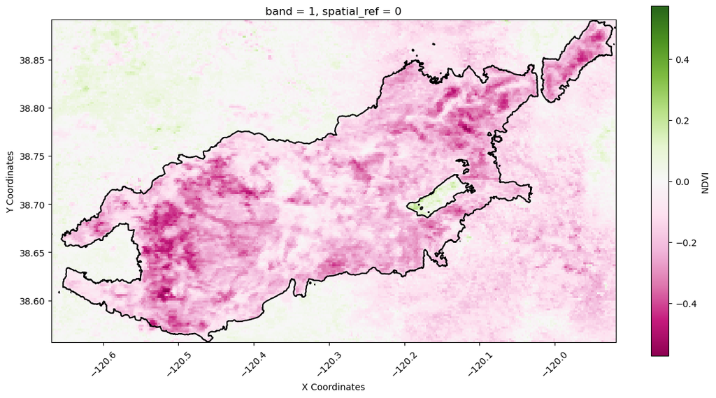

The figure displays the spatial NDVI mean difference values between 2020 and 2023 in the Caldor Fire area. Positive differences, shown in green, indicate increased vegetation, while negative differences, in purple, signify sparse or decreased vegetation. This map visually captures changes in vegetation density, offering insights into post-fire recovery and areas facing persistent challenges. The color-coded representation facilitates a quick understanding of the ecological impact, guiding targeted assessments and land management decisions.

Within the Caldor Fire boundary, NDVI values remain persistently low, signaling ongoing challenges in vegetation recovery. The aftermath of the wildfire has left a profound impact on the landscape, with severely damaged or completely burned vegetation contributing to depressed NDVI readings. The persistent low values suggest a slow regrowth and rehabilitation process, highlighting the prolonged impact of the fire on the ecosystem. Monitoring and analyzing these NDVI trends within the fire-affected area are crucial for assessing the extent of ecological damage and informing targeted interventions and land management strategies to support the recovery of the affected vegetation.